# Regulation of Differential APA in cell body

Idiap Research Institute

February 2023

```r
plotEnrichAlongUTRfocusMerged <- function(mots="CPSF160_iClip",sel=c(20:30),cond="NGF",scaling=TRUE){

  if(cond=="NGF"){
    myX  = -unlist(lapply(myranges,mean))[sel]
    myIp = ttest_APA_NGF_Ip[match(mots,rownames(ttest_APA_NGF_Ip)),sel]
    myId = ttest_APA_NGF_Id[match(mots,rownames(ttest_APA_NGF_Id)),sel]
    if(scaling){
      myIp <- myIp/max(abs(myIp))
      myId <- myId/max(abs(myId))
    }
    plot(myX,myIp,col="white",las=1,ylab="-log10(P-value)",frame=FALSE,xlab="distante to 3'end",ylim=c(min(c(myIp,myId),na.rm=TRUE),max(c(myIp,myId),na.rm=TRUE)))
    abline(h=0,col="black")
    abline(v=0,col="red",lty=2)
    lines(myX,myIp,col="black",lwd=1.5)
    lines(myX,myId,col="grey",lwd=1.5)
    points(myX,myIp,col="black",pch=19)
    points(myX,myId,col="grey",pch=19)
    mtext(side=2,line=2,text=mots,font=1,cex=0.5)
    mtext(side=3,line=0,text="NGF",font=1,cex=0.5)
  }


  if(cond=="NT3"){
    myX  = -unlist(lapply(myranges,mean))[sel]
    myIp = ttest_APA_NT3_Ip[match(mots,rownames(ttest_APA_NT3_Ip)),sel]
    myId = ttest_APA_NT3_Id[match(mots,rownames(ttest_APA_NT3_Id)),sel]
    plot(myX,myIp,col="white",las=1,ylab="-log10(P-value)",frame=FALSE,xlab="distante to 3'end",ylim=c(min(c(myIp,myId),na.rm=TRUE),max(c(myIp,myId),na.rm=TRUE)))
    abline(h=0,col="black")
    abline(v=0,col="red",lty=2)
    lines(myX,myIp,col="black",lwd=1.5)
    lines(myX,myId,col="grey",lwd=1.5)
    points(myX,myIp,col="black",pch=19)
    points(myX,myId,col="grey",pch=19)
    mtext(side=2,line=2,text=mots,font=1,cex=0.5)
    mtext(side=3,line=0,text="NT3",font=1,cex=0.5)
  }

  if(cond=="diff"){
    myX  = -unlist(lapply(myranges,mean))[sel]
    myIp = ttest_diffAPA_Ip[match(mots,rownames(ttest_diffAPA_Ip)),sel]
    myId = ttest_diffAPA_Ip[match(mots,rownames(ttest_diffAPA_Ip)),sel]
    plot(myX,myIp,col="white",las=1,ylab="-log10(P-value)",frame=FALSE,xlab="distante to 3'end",ylim=c(min(c(myIp,myId),na.rm=TRUE),max(c(myIp,myId),na.rm=TRUE)))
    abline(h=0,col="black")
    abline(v=0,col="red",lty=2)
    lines(myX,myIp,col="black",lwd=1.5)
    lines(myX,myId,col="grey",lwd=1.5)
    points(myX,myIp,col="black",pch=19)
    points(myX,myId,col="grey",pch=19)
    mtext(side=2,line=2,text=mots,font=1,cex=0.5)
    mtext(side=3,line=0,text="diff",font=1,cex=0.5)
  }
}

#PlotPUD_CLIP(mymots="HuR_iClip",myrange="[100:50]")
#PlotPUD_CLIP(mymots="HuR_iClip",myrange="[50:0]")
#PlotPUD_CLIP(mymots="HuR_iClip",myrange="[0:-50]")
#PlotPUD_CLIP(mymots="HuR_iClip",myrange="[-50:-100]")
#PlotPUD_CLIP(mymots="HuR_iClip",myrange="[-100:-150]")

PlotPUD_CLIP <- function(mymots="UPF1_1_K652",myrange="[100:50]"){
  IX_M                 <- match(mymots,colnames(myClips[[match(myrange,mynames_rages)]]))
  clip                 <- myClips[[match(myrange,mynames_rages)]][,IX_M]
  names(clip)          <- rownames(myClips[[match(myrange,mynames_rages)]])
  #Proximal sites
  #
  no.sites <- clip[match(myOut$id.proximal,names(clip))]
  myIp      <- list(NGF=list(unbound=myOut$PUD.NGF.cb[no.sites==0],
                        bound=myOut$PUD.NGF.cb[no.sites>0]),
                    NT3=list(unbound=myOut$PUD.NT3.cb[no.sites==0],
                        bound=myOut$PUD.NT3.cb[no.sites>0]),
                    diff=list(unbound=myOut$dPUD[no.sites==0],
                         bound=myOut$dPUD[no.sites>0]))
  myno <- lapply(myIp,function(Z)return(lapply(Z,length)))

  par(mfrow=c(2,3))
  boxplot(myIp[[1]],col=colsNGF[1],las=1,frame=FALSE,outline=FALSE,ylim=c(0,1),ylab="PUD")
  mtext(side=1,line=2,at=c(1,2),text=unlist(myno[[1]]),cex=0.7)
  mtext(side=3,line=0,text=paste("P=",format(10^(-abs(ttest_APA_NGF_Ip[match(mymots,rownames(ttest_APA_NGF_Ip)),match(myrange,colnames(ttest_APA_NGF_Ip))])),digits=2,scientific=TRUE),sep=""),cex=0.7)


  boxplot(myIp[[2]],col=colsNT3[1],las=1,frame=FALSE,outline=FALSE,ylim=c(0,1),main=paste(mymots,"in",myrange),xlab="proximal")
  mtext(side=1,line=2,at=c(1,2),text=unlist(myno[[2]]),cex=0.7)
  mtext(side=3,line=0,text=paste("P=",format(10^(-abs(ttest_APA_NT3_Ip[match(mymots,rownames(ttest_APA_NT3_Ip)),match(myrange,colnames(ttest_APA_NT3_Ip))])),digits=2,scientific=TRUE),sep=""),cex=0.7)

  boxplot(myIp[[3]],col="grey",las=1,frame=FALSE,outline=FALSE)
  mtext(side=1,line=2,at=c(1,2),text=unlist(myno[[3]]),cex=0.7)
  mtext(side=3,line=0,text=paste("P=",format(10^(-abs(ttest_diffAPA_Ip[match(mymots,rownames(ttest_diffAPA_Ip)),match(myrange,colnames(ttest_diffAPA_Ip))])),digits=2,scientific=TRUE),sep=""),cex=0.7)

  #Distal sites
  #
  no.sites <- clip[match(myOut$id.distal,names(clip))]
  myId     <- list(NGF=list(unbound=myOut$PUD.NGF.cb[no.sites==0],
                             bound=myOut$PUD.NGF.cb[no.sites>0]),
                    NT3=list(unbound=myOut$PUD.NT3.cb[no.sites==0],
                             bound=myOut$PUD.NT3.cb[no.sites>0]),
                    diff=list(unbound=myOut$dPUD[no.sites==0],
                              bound=myOut$dPUD[no.sites>0]))

  myno <- lapply(myId,function(Z)return(lapply(Z,length)))

  boxplot(myId[[1]],col=colsNGF[1],las=1,frame=FALSE,outline=FALSE,ylim=c(0,1),ylab="PUD")
  mtext(side=1,line=2,at=c(1,2),text=unlist(myno[[1]]),cex=0.7)
  mtext(side=3,line=0,text=paste("P=",format(10^(-abs(ttest_APA_NGF_Id[match(mymots,rownames(ttest_APA_NGF_Id)),match(myrange,colnames(ttest_APA_NGF_Id))])),digits=2,scientific=TRUE),sep=""),cex=0.7)


  boxplot(myId[[2]],col=colsNT3[1],las=1,frame=FALSE,outline=FALSE,ylim=c(0,1),main=paste(mymots,"in",myrange),xlab="distal")
  mtext(side=1,line=2,at=c(1,2),text=unlist(myno[[2]]),cex=0.7)
  mtext(side=3,line=0,text=paste("P=",format(10^(-abs(ttest_APA_NT3_Id[match(mymots,rownames(ttest_APA_NT3_Id)),match(myrange,colnames(ttest_APA_NT3_Id))])),digits=2,scientific=TRUE),sep=""),cex=0.7)


  boxplot(myId[[3]],col="grey",las=1,frame=FALSE,outline=FALSE)
  mtext(side=1,line=2,at=c(1,2),text=unlist(myno[[3]]),cex=0.7)
  mtext(side=3,line=0,text=paste("P=",format(10^(-abs(ttest_diffAPA_Ip[match(mymots,rownames(ttest_diffAPA_Id)),match(myrange,colnames(ttest_diffAPA_Id))])),digits=2,scientific=TRUE),sep=""),cex=0.7)

}


SelectPositive <- function(mat){
  mat[mat<0]<-NA
  return(mat)
}
SelectNegative <- function(mat){
  mat[mat>0]<-NA
  return(mat)
}

plotLineWithSD<-function(x=(-unlist(lapply(myranges,mean))[-1]),mymat=fisher_proxi_NGF_reg,col1="#81A4D6",col2=rgb(129/255,164/255,214/255,0.3),YLIM=c(-2,2),YLAB="Ip Fisher Enrichment",MAIN="Proximal"){
  mean_force=apply(mymat,2,function(W)return(median(W,na.rm=TRUE)))
  mean_force[is.na(mean_force)]<-0
  sd=apply(mymat,2,function(W)return(sd(W,na.rm=TRUE)))
  sd[is.na(sd)]<-0
  psd<-mean_force+sd
  nsd<-mean_force-sd
  plot(x, mean_force, ty="l", col=col1, ylab="", lty=1,lwd=3,las=1,frame=FALSE,ylim=YLIM,xlab="")
  lines(x, psd,col=col2)
  lines(x, nsd,col=col2)
  polygon(x=c(x, rev(x)), y=c(psd, rev(nsd)), col=col2,border=col2)
  lines(x, mean_force, col=col1,lwd=3)
  abline(h=0,col="black")
  mtext(side=3,line=0,text=MAIN,cex=0.7)
  mtext(side=1,line=2,text="distance from 3' end",cex=0.7)
  mtext(side=2,line=2,text=YLAB,cex=0.7)
}
```

Integration with human clip-sequencing data mapped to HG19 genome and lifted-over the Rn5 genome.

# 1 Load the data

3' UTR isoform quantification from 8 samples originating from rat neuronal sympathetic cell cultures where the cell body is treated with low does of NGF and distal axons are either exposed to NGF or NT3. There are a total of 8 samples: cell body versus distal axons in NGF versus NT3 culture condition across 2 technical replicates.

```r
#load("./data/myfiles.RData")#"anno_tot","myUTR"

#load("./data/files_analysis_Nov2017.RData")
#
#load("~/Desktop/DataAnalsyisRiccio/NGFvsNT3/files_analysis_Sep2017.RData")#Version September 2017 (remove 10% antisense)32632 3' UTR isoforms
#myUTR        <- import.gff("./data/myUTR.gtf",format="gtf")
#anno_tot     <- read.delim("./data/anno_tot.tab",header=TRUE,sep="\t")
source("./scripts/nested_fun_differential_PAS.R")
source("./scripts/nested_fun_nt3_ngf.R")
source("./scripts/nested_fun_APA_CB.R")
#myOut        <- read.csv("./zenodo/apa/apa.csv")
load("./zenodo/files_analysis_Nov2017.RData")
load("./zenodo/apa/myOut_nov2017.RData")#myOut

proxi_ngf    <- read.csv("./zenodo/apa/distal_to_proxi_ngf.csv")
proxi_ngf    <- read.csv("./zenodo/apa/distal_to_proxi_nt3.csv")
res.filt.ngf <- list(read.csv("./zenodo/apa/dist_NT3_filtered_stringent.csv"),
                     read.csv("./zenodo/apa/proxi_NGF_filtered_stringent.csv"))

res.filt.nt3 <- list(read.csv("./zenodo/apa/dist_NGF_filtered_stringent.csv"),
                     read.csv("./zenodo/apa/proxi_NT3_filtered_stringent.csv"))

#Load Clip object
names_files     <- c("APA_NGF","APA_NT3","dAPA_NGF_NT3")
myranges         <- list(c(100,-100),c(3000,2950),c(2750,2700),c(2500,2450),c(2250,2200),c(2000,1950),c(1750,1700),c(1500,1450),c(1400,1350),c(1300,1250),c(1200,1150),c(1100,1050),c(1000,950),c(900,850),c(800,750),c(700,650),c(600,550),c(500,450),c(450,400),c(400,350),c(350,300),c(300,250),c(250,200),c(200,150),c(150,100),c(100,50),c(50,0),c(0,-50),c(-50,-100),c(-100,-150))
mynames_rages   <- unlist(lapply(myranges,function(Z)return(paste("[",Z[[1]],":",Z[[2]],"]",sep=""))))

load("./zenodo/clips.RData")#"myClips","myranges","mynames_rages"
#List of 30 objects == for 30 regions along 3' UTR region, we collect the number of cross-link events per 3' UTR isoforms. Matrix [37513 X 335] with 37,513 isoforms and 335 clip data.
load("./zenodo/utrsConScores.RData")#Conservation scores of 3' UTR in ConservationScoresUTRs object
```

# 2 Overview of the conservation scores and RBP clip densities along 3' UTR

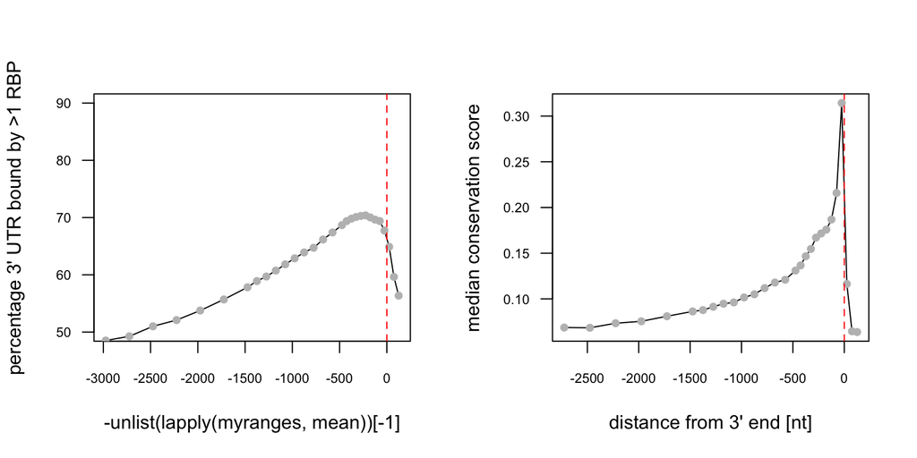

```r
no_rbp_bound            <- matrix(nrow=nrow(myClips[[1]]),ncol=length(myranges),0)
rownames(no_rbp_bound)  <- rownames(myClips[[1]])
colnames(no_rbp_bound)  <- mynames_rages

for(IX in c(1:length(mynames_rages))){
  clipdat            <- myClips[[IX]]
  #rownames(clipdat)  <- rownames(myClips[[IX]])
  #clipdat            <- clipdat[match(as.character(diff.transport.neurotrophins$uniqueIDs),rownames(clipdat)),]
  no_rbp_bound[,IX]  <- apply(clipdat>0,1,sum)
}

par(mfrow=c(1,2))
plot(x=-unlist(lapply(myranges,mean))[-1],y=100*apply(no_rbp_bound>1,2,function(Z)return(sum(Z,na.rm=TRUE)))[-1]/nrow(no_rbp_bound),las=1,cex.axis=0.7,cex.names=0.7,ylab="percentage 3' UTR bound by >1 RBP",type="l",pch=19,col="black",ylim=c(50,90),cex=0.8)
points(x=-unlist(lapply(myranges,mean))[-1],y=100*apply(no_rbp_bound>1,2,function(Z)return(sum(Z,na.rm=TRUE)))[-1]/nrow(no_rbp_bound),pch=19,col="grey",cex=0.8)
abline(v=0,col="red",lty=2)

myX=-unlist(lapply(myranges[match(colnames(ConservationScoresUTRs),mynames_rages)],mean))[-1]
plot(x=myX,y=apply(ConservationScoresUTRs,2,function(Z)return(median(Z,na.rm=TRUE)))[-1],las=1,cex.axis=0.7,cex.names=0.7,ylab="median conservation score",xlab="distance from 3' end [nt]",type="l",pch=19,col="black",cex=0.8)
points(x=myX,y=apply(ConservationScoresUTRs,2,function(Z)return(median(Z,na.rm=TRUE)))[-1],pch=19,col="grey",cex=0.8)
abline(v=0,col="red",lty=2)
```

# 3 Analysis of global regulators of APA using Welch's t-test

We first test the association between RBP clip events and 3' UTR usage in each conditions (NGF and NT3) using the Welch's t-test. Specifically we iteratively test for significantly different distributions between PUD scores of 3' UTR isoforms exhibiting or not a cross-link event in specific region along the 3' UTR. We test the association between PUD and binding in short 3' UTR as well as the association between PUD and binding in long 3' UTR.

```r
#Load Clip object
names_files     <- c("APA_NGF","APA_NT3","dAPA_NGF_NT3")
myranges         <- list(c(100,-100),c(3000,2950),c(2750,2700),c(2500,2450),c(2250,2200),c(2000,1950),c(1750,1700),c(1500,1450),c(1400,1350),c(1300,1250),c(1200,1150),c(1100,1050),c(1000,950),c(900,850),c(800,750),c(700,650),c(600,550),c(500,450),c(450,400),c(400,350),c(350,300),c(300,250),c(250,200),c(200,150),c(150,100),c(100,50),c(50,0),c(0,-50),c(-50,-100),c(-100,-150))
mynames_rages   <- unlist(lapply(myranges,function(Z)return(paste("[",Z[[1]],":",Z[[2]],"]",sep=""))))
load("./zenodo/clips.RData")#"myClips","myranges","mynames_rages"


#
#RELATIONSHIP BETWEEN PROXIMAL RELATIVE EXPRESSION (Ip) AND RBP CROSS-LINK EVENT
#WELSCH TEST
#
myTtest_APA_CB_Ip_Welsch <- list()
for(ix in c(1:length(mynames_rages))){
  clipdat            <- myClips[[ix]]
  ix_row             <- match(as.character(myOut$id.proximal),rownames(clipdat))
  print(sum(is.na(ix_row)))
  clipdat            <- clipdat[ix_row[!is.na(ix_row)],]
  temp_out           <- myOut[!is.na(ix_row),]


  myTtest_APA_CB_Ip_Welsch[[ix]]           <- matrix(0,ncol=3,nrow=ncol(clipdat))
  colnames(myTtest_APA_CB_Ip_Welsch[[ix]]) <- c("NGF_ttest","NT3_ttest","diff_PUD_ttest")
  rownames(myTtest_APA_CB_Ip_Welsch[[ix]]) <- colnames(clipdat)
  for(colix in c(1:ncol(clipdat))){
    no.sites          <- clipdat[,colix]
    myX               <- temp_out$PUD.NGF.cb[no.sites==0]
    myY               <- temp_out$PUD.NGF.cb[no.sites>0]
    myTtest_APA_CB_Ip_Welsch[[ix]][colix,1] <- -log10(t.test(x=myX,y=myY,var.equal = FALSE)$p.value)*sign(mean(myY,na.rm=TRUE)-mean(myX,na.rm=TRUE))


    myX               <- temp_out$PUD.NT3.cb[no.sites==0]
    myY               <- temp_out$PUD.NT3.cb[no.sites>0]
    myTtest_APA_CB_Ip_Welsch[[ix]][colix,2] <- -log10(t.test(x=myX,y=myY,var.equal = FALSE)$p.value)*sign(mean(myY,na.rm=TRUE)-mean(myX,na.rm=TRUE))


    myX               <- temp_out$dPUD[no.sites==0]
    myY               <- temp_out$dPUD[no.sites>0]
    myTtest_APA_CB_Ip_Welsch[[ix]][colix,3] <- -log10(t.test(x=myX,y=myY,var.equal = FALSE)$p.value)*sign(mean(myY,na.rm=TRUE)-mean(myX,na.rm=TRUE))
    #print(colix)
  }
}

ttest_APA_NGF_Ip              <- do.call(lapply(myTtest_APA_CB_Ip_Welsch,function(TTest)return(TTest[,1])),what=cbind)
colnames(ttest_APA_NGF_Ip)    <- mynames_rages
rownames(ttest_APA_NGF_Ip)    <- rownames(myTtest_APA_CB_Ip_Welsch[[1]])


ttest_APA_NT3_Ip              <- do.call(lapply(myTtest_APA_CB_Ip_Welsch,function(TTest)return(TTest[,2])),what=cbind)
colnames(ttest_APA_NT3_Ip)    <- mynames_rages
rownames(ttest_APA_NT3_Ip)    <- rownames(myTtest_APA_CB_Ip_Welsch[[1]])

ttest_diffAPA_Ip             <- do.call(lapply(myTtest_APA_CB_Ip_Welsch,function(TTest)return(TTest[,3])),what=cbind)
colnames(ttest_diffAPA_Ip)    <- mynames_rages
rownames(ttest_diffAPA_Ip)    <- rownames(myTtest_APA_CB_Ip_Welsch[[1]])


#
#RELATIONSHIP BETWEEN DISTAL RELATIVE EXPRESSION (Id) AND RBP CROSS-LINK EVENT
#WELSCH TEST
#
myTtest_APA_CB_Id_Welsch <- list()
for(ix in c(1:length(mynames_rages))){
  clipdat            <- myClips[[ix]]

  ix_row             <- match(as.character(myOut$id.distal),rownames(clipdat))
  print(sum(is.na(ix_row)))
  clipdat            <- clipdat[ix_row[!is.na(ix_row)],]
  temp_out           <- myOut[!is.na(ix_row),]

  myTtest_APA_CB_Id_Welsch[[ix]]           <- matrix(0,ncol=3,nrow=ncol(clipdat))
  colnames(myTtest_APA_CB_Id_Welsch[[ix]]) <- c("NGF_ttest","NT3_ttest","diff_PUD_ttest")
  rownames(myTtest_APA_CB_Id_Welsch[[ix]]) <- colnames(clipdat)
  for(colix in c(1:ncol(clipdat))){
    no.sites          <- clipdat[,colix]
    myX               <- temp_out$PUD.NGF.cb[no.sites==0]
    myY               <- temp_out$PUD.NGF.cb[no.sites>0]
    myTtest_APA_CB_Id_Welsch[[ix]][colix,1] <- -log10(t.test(x=myX,y=myY,var.equal = FALSE)$p.value)*sign(mean(myY,na.rm=TRUE)-mean(myX,na.rm=TRUE))


    myX               <- temp_out$PUD.NT3.cb[no.sites==0]
    myY               <- temp_out$PUD.NT3.cb[no.sites>0]
    myTtest_APA_CB_Id_Welsch[[ix]][colix,2] <- -log10(t.test(x=myX,y=myY,var.equal = FALSE)$p.value)*sign(mean(myY,na.rm=TRUE)-mean(myX,na.rm=TRUE))


    myX               <- temp_out$dPUD[no.sites==0]
    myY               <- temp_out$dPUD[no.sites>0]
    myTtest_APA_CB_Id_Welsch[[ix]][colix,3] <- -log10(t.test(x=myX,y=myY,var.equal = FALSE)$p.value)*sign(mean(myY,na.rm=TRUE)-mean(myX,na.rm=TRUE))
    #print(colix)
  }
}

ttest_APA_NGF_Id              <- do.call(lapply(myTtest_APA_CB_Id_Welsch,function(TTest)return(TTest[,1])),what=cbind)
colnames(ttest_APA_NGF_Id)    <- mynames_rages
rownames(ttest_APA_NGF_Id)    <- rownames(myTtest_APA_CB_Id_Welsch[[1]])

ttest_APA_NT3_Id              <- do.call(lapply(myTtest_APA_CB_Id_Welsch,function(TTest)return(TTest[,2])),what=cbind)
colnames(ttest_APA_NT3_Id)    <- mynames_rages
rownames(ttest_APA_NT3_Id)    <- rownames(myTtest_APA_CB_Id_Welsch[[1]])

ttest_diffAPA_Id             <- do.call(lapply(myTtest_APA_CB_Id_Welsch,function(TTest)return(TTest[,3])),what=cbind)
colnames(ttest_diffAPA_Id)    <- mynames_rages
rownames(ttest_diffAPA_Id)    <- rownames(myTtest_APA_CB_Id_Welsch[[1]])


#save(list=c("ttest_APA_NGF_Ip","ttest_APA_NT3_Ip","ttest_diffAPA_Ip","ttest_APA_NGF_Id","ttest_APA_NT3_Id","ttest_diffAPA_Id"),file="./zenodo/apa/regulation/welch.RData")
```

We can now look at the distributions of the P-value around the 3' end to identify key regulatory regions.

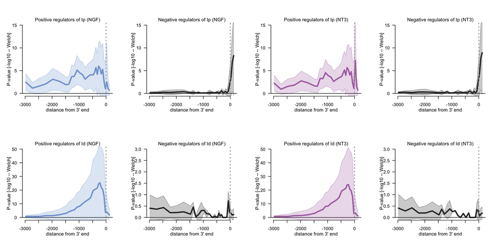

```r
load("./zenodo/apa/regulation/welch.RData")
coldiff <- c("grey",rgb(0,0,0,0.15))
colNGF <- c("#81A4D6",rgb(129/255,164/255,214/255,0.25))
colNT3 <- c("#AE72B0",rgb(174/255,114/255,176/255,0.25))
colPOS <- c("#991721",rgb(153/255,23/255,33/255,0.25))
colNEG <- c("#313332",rgb(49/255,51/255,50/255,0.25))


colsNGF <- c("#81A4D6",rgb(129/255,164/255,214/255,0.25))
colsNT3 <- c("#AE72B0",rgb(174/255,114/255,176/255,0.25))


par(mfrow=c(2,4))#Try to test the difference between the positive and the negative regulators
plotLineWithSD(x=(-unlist(lapply(myranges,mean))[-1]),mymat=SelectPositive(ttest_APA_NGF_Ip)[,-1],col1=colNGF[1],col2=colNGF[2],YLIM=c(0,15),YLAB="P-value [-log10 -- Welch]",MAIN="Positive regulators of Ip (NGF)")
abline(v=0,col="darkgrey",lty=3,lwd=2)
plotLineWithSD(x=(-unlist(lapply(myranges,mean))[-1]),mymat=abs(SelectNegative(ttest_APA_NGF_Ip))[,-1],col1=colNEG[1],col2=colNEG[2],YLIM=c(0,15),YLAB="P-value [-log10 -- Welch]",MAIN="Negative regulators of Ip (NGF)")
abline(v=0,col="darkgrey",lty=3,lwd=2)

plotLineWithSD(x=(-unlist(lapply(myranges,mean))[-1]),mymat=SelectPositive(ttest_APA_NT3_Ip)[,-1],col1=colsNT3[1],col2=colsNT3[2],YLIM=c(0,15),YLAB="P-value [-log10 -- Welch]",MAIN="Positive regulators of Ip (NT3)")
abline(v=0,col="darkgrey",lty=3,lwd=2)
plotLineWithSD(x=(-unlist(lapply(myranges,mean))[-1]),mymat=abs(SelectNegative(ttest_APA_NT3_Ip))[,-1],col1=colNEG[1],col2=colNEG[2],YLIM=c(0,15),YLAB="P-value [-log10 -- Welch]",MAIN="Negative regulators of Ip (NT3)")
abline(v=0,col="darkgrey",lty=3,lwd=2)


plotLineWithSD(x=(-unlist(lapply(myranges,mean))[-1]),mymat=abs(SelectNegative(ttest_APA_NGF_Id)[,-1]),col1=colNGF[1],col2=colNGF[2],YLIM=c(0,50),YLAB="P-value [-log10 -- Welch]",MAIN="Positive regulators of Id (NGF)")
abline(v=0,col="darkgrey",lty=3,lwd=2)
plotLineWithSD(x=(-unlist(lapply(myranges,mean))[-1]),mymat=SelectPositive(ttest_APA_NGF_Id)[,-1],col1=colNEG[1],col2=colNEG[2],YLIM=c(0,3),YLAB="P-value [-log10 -- Welch]",MAIN="Negative regulators of Id (NGF)")
abline(v=0,col="darkgrey",lty=3,lwd=2)


plotLineWithSD(x=(-unlist(lapply(myranges,mean))[-1]),mymat=abs(SelectNegative(ttest_APA_NT3_Id)[,-1]),col1=colsNT3[1],col2=colsNT3[2],YLIM=c(0,50),YLAB="P-value [-log10 -- Welch]",MAIN="Positive regulators of Id (NT3)")
abline(v=0,col="darkgrey",lty=3,lwd=2)
plotLineWithSD(x=(-unlist(lapply(myranges,mean))[-1]),mymat=SelectPositive(ttest_APA_NT3_Id)[,-1],col1=colNEG[1],col2=colNEG[2],YLIM=c(0,3),YLAB="P-value [-log10 -- Welch]",MAIN="Negative regulators of Id (NT3)")
abline(v=0,col="darkgrey",lty=3,lwd=2)
```

## 3.1 Global positive regulators of APA

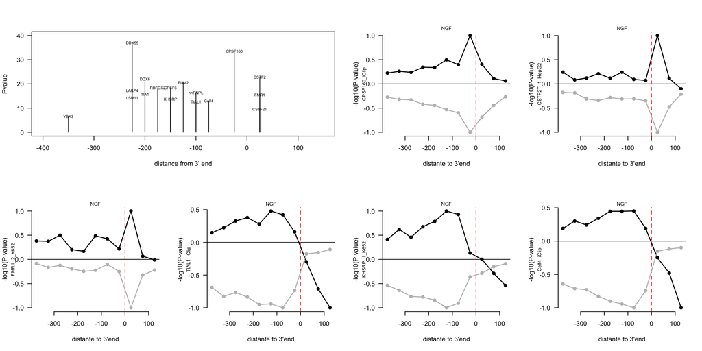

```r
global_positive             <- lapply(c(1:ncol(ttest_APA_NGF_Ip)),function(W)return(unlist(lapply(ExtractTopRegulatorsSimple(sub2=cbind(ttest_APA_NGF_Ip[,W],-ttest_APA_NGF_Id[,W])),function(IX)return(rownames(ttest_APA_NGF_Ip)[IX])))))
global_positive_names <- lapply(global_positive,function(W)return(unique(unlist(lapply(W,function(Z)return((unlist(strsplit(Z,split="_"))[1])))))))
names(global_positive_names) <- myranges
myPositive                   <- unique(unlist(global_positive_names))
MOTS_POS                     <-unique(unlist(global_positive))
START <- unlist(lapply(myranges,function(Z)return(-Z[1])))
END   <- unlist(lapply(myranges,function(Z)return(-Z[2])))
ROI                          <- mynames_rages[unlist(lapply(MOTS_POS,function(mymot)sort(-ttest_APA_NGF_Id[match(mymot,rownames(ttest_APA_NGF_Id)),-1],decreasing=TRUE,index.return=TRUE)$ix[1]+1))]
ROIp <- mynames_rages[unlist(lapply(MOTS_POS,function(mymot)sort(ttest_APA_NGF_Ip[match(mymot,rownames(ttest_APA_NGF_Ip)),-1],decreasing=TRUE,index.return=TRUE)$ix[1]+1))]

ValuesOI_Ip                    <- unlist(mapply(A=MOTS_POS,B=ROI,function(A,B){
  ttest_APA_NGF_Ip[match(A,rownames(ttest_APA_NGF_Ip)),match(B,colnames(ttest_APA_NGF_Ip))]
}))
ValuesOI_Id                    <- -unlist(mapply(A=MOTS_POS,B=ROI,function(A,B){
  ttest_APA_NGF_Id[match(A,rownames(ttest_APA_NGF_Id)),match(B,colnames(ttest_APA_NGF_Id))]
}))


global_positive_regulators <- data.frame(Clip=MOTS_POS,
                            GS=unlist(lapply(MOTS_POS,function(Z)return((unlist(strsplit(Z,split="_"))[1])))),
                                         start.Ip=START[match(ROIp,mynames_rages)],
                                         end.Ip=END[match(ROIp,mynames_rages)],
                                         start.Id=START[match(ROI,mynames_rages)],
                                         end.Id=END[match(ROI,mynames_rages)],
                                         max_vals_Ip=ValuesOI_Ip,
                                         max_vals_Id=ValuesOI_Id)



sel<-which(!duplicated(global_positive_regulators$GS))
layout(matrix(c(1,1,2,3,4,5,6,7),byrow = TRUE,ncol=4,nrow=2))
plot(x=apply(cbind(apply(global_positive_regulators[sel,c("start.Ip","start.Id")],1,mean),
                   apply(global_positive_regulators[sel,c("end.Ip","end.Id")],1,mean)),1,mean),
     y=global_positive_regulators[sel,"max_vals_Ip"]
     ,col="black",
     type="h",xlim=c(-400,150),ylim=c(0,40),xlab="distance from 3' end",ylab="Pvalue",las=1)
text(x=apply(cbind(apply(global_positive_regulators[sel,c("start.Ip","start.Id")],1,mean),
                   apply(global_positive_regulators[sel,c("end.Ip","end.Id")],1,mean)),1,mean),
     y=global_positive_regulators[sel,"max_vals_Ip"],
     labels=global_positive_regulators$GS[sel],
     cex=0.6)

plotEnrichAlongUTRfocusMerged(mots="CPSF160_iClip",sel=c(20:30),cond="NGF",scaling=TRUE)
plotEnrichAlongUTRfocusMerged(mots="CSTF2T_1_HepG2",sel=c(20:30),cond="NGF")
plotEnrichAlongUTRfocusMerged(mots="FMR1_2_K652",sel=c(20:30),cond="NGF")
plotEnrichAlongUTRfocusMerged(mots="TIAL1_iClip",sel=c(20:30),cond="NGF")
plotEnrichAlongUTRfocusMerged(mots="KHSRP_1_K652",sel=c(20:30),cond="NGF")
plotEnrichAlongUTRfocusMerged(mots="Celf4_iClip",sel=c(20:30),cond="NGF")
```

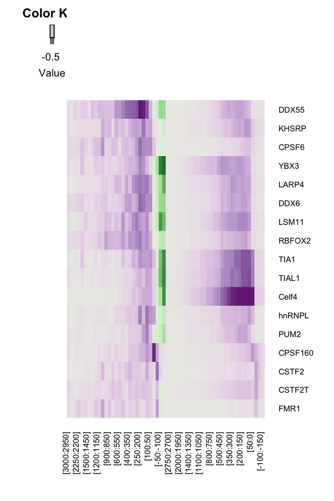

```r
PlotHeatmapRegulators(mots=unique(unlist(global_positive)),mymats=list(ttest_APA_NGF_Ip[,-1],-ttest_APA_NGF_Id[,-1]))
```

```r
##
##POSITIVE REGULATORS NGF
##
Ip_positive_NGF             <- lapply(c(1:ncol(ttest_APA_NGF_Ip)),function(W){
  LIMS <- boxplot(ttest_APA_NGF_Ip[,W],plot=FALSE)$stats[5,1]
  return(setdiff(rownames(ttest_APA_NGF_Ip)[(ttest_APA_NGF_Ip[,W])>LIMS],unique(unlist(global_positive))))
})
Ip_positive_NGF_names        <- lapply(Ip_positive_NGF,function(W)return(unique(unlist(lapply(W,function(Z)return((unlist(strsplit(Z,split="_"))[1])))))))
names(Ip_positive_NGF_names) <- myranges
Ip_positive_NGF_names <- Ip_positive_NGF_names[c(22:30)]
Ip_positive_NGF       <- Ip_positive_NGF[c(22:30)]
myPositiveNGF         <- unique(unlist(Ip_positive_NGF_names))
MOTS_POS              <-unique(unlist(Ip_positive_NGF))
START <- unlist(lapply(myranges,function(Z)return(-Z[1])))
END   <- unlist(lapply(myranges,function(Z)return(-Z[2])))
ROIp  <- mynames_rages[unlist(lapply(MOTS_POS,function(mymot)sort(ttest_APA_NGF_Ip[match(mymot,rownames(ttest_APA_NGF_Ip)),-1],decreasing=TRUE,index.return=TRUE)$ix[1]+1))]
ValuesOI                   <- unlist(mapply(A=MOTS_POS,B=ROIp,function(A,B){
  ttest_APA_NGF_Ip[match(A,rownames(ttest_APA_NGF_Ip)),match(B,colnames(ttest_APA_NGF_Ip))]
}))
Ip_positive_NGF_regulators <- data.frame(start.Ip=START[match(ROIp,mynames_rages)],
                                         end.Ip=END[match(ROIp,mynames_rages)],
                                         vals=ValuesOI,
                                         Clip=MOTS_POS,
                                         GS=unlist(lapply(MOTS_POS,function(Z)return((unlist(strsplit(Z,split="_"))[1])))))

##
##POSITIVE REGULATORS DISTAL NGF -Id
##
Id_positive_NGF             <- lapply(c(1:ncol(ttest_APA_NGF_Id)),function(W){
  LIMS <- boxplot(-ttest_APA_NGF_Id[,W],plot=FALSE)$stats[5,1]
  return(setdiff(rownames(ttest_APA_NGF_Id)[(-ttest_APA_NGF_Id[,W])>LIMS],unique(unlist(global_positive))))
})
Id_positive_NGF_names        <- lapply(Id_positive_NGF,function(W)return(unique(unlist(lapply(W,function(Z)return((unlist(strsplit(Z,split="_"))[1])))))))
names(Id_positive_NGF_names) <- myranges
Id_positive_NGF_names <- Id_positive_NGF_names[c(22:30)]
Id_positive_NGF       <- Id_positive_NGF[c(22:30)]
myPositiveNGF         <- unique(unlist(Id_positive_NGF_names))
MOTS_POS              <-unique(unlist(Id_positive_NGF))
START                 <- unlist(lapply(myranges,function(Z)return(-Z[1])))
END                   <- unlist(lapply(myranges,function(Z)return(-Z[2])))

ROIp                       <- mynames_rages[unlist(lapply(MOTS_POS,function(mymot)sort(-ttest_APA_NGF_Ip[match(mymot,rownames(ttest_APA_NGF_Ip)),-1],decreasing=TRUE,index.return=TRUE)$ix[1]+1))]
ValuesOI                   <- -unlist(mapply(A=MOTS_POS,B=ROIp,function(A,B){
  -ttest_APA_NGF_Ip[match(A,rownames(ttest_APA_NGF_Ip)),match(B,colnames(ttest_APA_NGF_Ip))]
}))


ROId  <- mynames_rages[unlist(lapply(MOTS_POS,function(mymot)sort(-ttest_APA_NGF_Id[match(mymot,rownames(ttest_APA_NGF_Id)),-1],decreasing=TRUE,index.return=TRUE)$ix[1]+1))]
ValuesOI_Id                   <- unlist(mapply(A=MOTS_POS,B=ROId,function(A,B){
  ttest_APA_NGF_Id[match(A,rownames(ttest_APA_NGF_Id)),match(B,colnames(ttest_APA_NGF_Id))]
}))

Id_positive_NGF_regulators <- data.frame(start.Ip=START[match(ROIp,mynames_rages)],
                                         end.Ip=END[match(ROIp,mynames_rages)],
                                         start.Id=START[match(ROId,mynames_rages)],
                                         end.Id=END[match(ROId,mynames_rages)],
                                         Clip=MOTS_POS,
                                         vals_Ip=ValuesOI,
                                         vals_Id=ValuesOI_Id,
                                         GS=unlist(lapply(MOTS_POS,function(Z)return((unlist(strsplit(Z,split="_"))[1])))))

Id_positive_NGF_regulators <- Id_positive_NGF_regulators[!Id_positive_NGF_regulators$GS%in%c("CSTF2T","KHDRBS1","U2AF2"),]
Id_positive_NGF_regulators <- Id_positive_NGF_regulators[!Id_positive_NGF_regulators$GS%in%Ip_positive_NGF_regulators$GS,]


##
##POSITIVE REGULATORS NT3
##
Ip_positive_NT3             <- lapply(c(1:ncol(ttest_APA_NT3_Ip)),function(W){
  LIMS <- boxplot(ttest_APA_NT3_Ip[,W],plot=FALSE)$stats[5,1]
  return(setdiff(rownames(ttest_APA_NT3_Ip)[(ttest_APA_NT3_Ip[,W])>LIMS],unique(unlist(global_positive))))
})
Ip_positive_NT3_names        <- lapply(Ip_positive_NT3,function(W)return(unique(unlist(lapply(W,function(Z)return((unlist(strsplit(Z,split="_"))[1])))))))
names(Ip_positive_NT3_names) <- myranges
Ip_positive_NT3_names <- Ip_positive_NT3_names[c(22:30)]
Ip_positive_NT3       <- Ip_positive_NT3[c(22:30)]
myPositiveNT3         <- unique(unlist(Ip_positive_NT3_names))
MOTS_POS              <-unique(unlist(Ip_positive_NT3))
START <- unlist(lapply(myranges,function(Z)return(-Z[1])))
END   <- unlist(lapply(myranges,function(Z)return(-Z[2])))
ROIp  <- mynames_rages[unlist(lapply(MOTS_POS,function(mymot)sort(ttest_APA_NT3_Ip[match(mymot,rownames(ttest_APA_NT3_Ip)),-1],decreasing=TRUE,index.return=TRUE)$ix[1]+1))]
ValuesOI                   <- unlist(mapply(A=MOTS_POS,B=ROIp,function(A,B){
  ttest_APA_NT3_Ip[match(A,rownames(ttest_APA_NT3_Ip)),match(B,colnames(ttest_APA_NT3_Ip))]
}))
Ip_positive_NT3_regulators <- data.frame(start.Ip=START[match(ROIp,mynames_rages)],
                                         end.Ip=END[match(ROIp,mynames_rages)],
                                         vals=ValuesOI,
                                         Clip=MOTS_POS,
                                         GS=unlist(lapply(MOTS_POS,function(Z)return((unlist(strsplit(Z,split="_"))[1])))))
```

## 3.2 Global negative regulators of APA

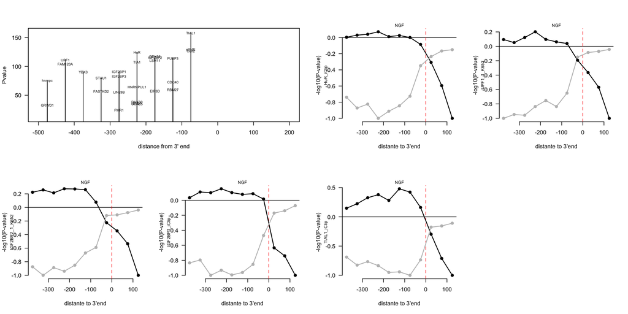

```r
global_negative             <- lapply(c(1:ncol(ttest_APA_NGF_Ip)),function(W){
  LIMS <- boxplot(-ttest_APA_NGF_Ip[,W],plot=FALSE)$stats[5,1]
  return(rownames(ttest_APA_NGF_Ip)[(-ttest_APA_NGF_Ip[,W])>=LIMS])

})

global_negative_names         <- lapply(global_negative,function(W)return(unique(unlist(lapply(W,function(Z)return((unlist(strsplit(Z,split="_"))[1])))))))
names(global_negative_names) <- myranges
myNegative                   <- unique(unlist(global_negative_names))
MOTS_NEG                   <-unique(unlist(global_negative))
START                      <- unlist(lapply(myranges,function(Z)return(-Z[1])))
END                        <- unlist(lapply(myranges,function(Z)return(-Z[2])))
ROIp                       <- mynames_rages[unlist(lapply(MOTS_NEG,function(mymot)sort(-ttest_APA_NGF_Ip[match(mymot,rownames(ttest_APA_NGF_Ip)),-1],decreasing=TRUE,index.return=TRUE)$ix[1]+1))]
ValuesOI                   <- -unlist(mapply(A=MOTS_NEG,B=ROIp,function(A,B){
  -ttest_APA_NGF_Ip[match(A,rownames(ttest_APA_NGF_Ip)),match(B,colnames(ttest_APA_NGF_Ip))]
}))


ROId  <- mynames_rages[unlist(lapply(MOTS_NEG,function(mymot)sort(-ttest_APA_NGF_Id[match(mymot,rownames(ttest_APA_NGF_Id)),-1],decreasing=TRUE,index.return=TRUE)$ix[1]+1))]
ValuesOI_Id                   <- unlist(mapply(A=MOTS_NEG,B=ROId,function(A,B){
  ttest_APA_NGF_Id[match(A,rownames(ttest_APA_NGF_Id)),match(B,colnames(ttest_APA_NGF_Id))]
}))


global_negative_regulators <- data.frame(start.Ip=START[match(ROIp,mynames_rages)],
                                         end.Ip=END[match(ROIp,mynames_rages)],
                                         start.Id=START[match(ROId,mynames_rages)],
                                         end.Id=END[match(ROId,mynames_rages)],
                                         Clip=MOTS_NEG,
                                         vals_Ip=ValuesOI,
                                         vals_Id=ValuesOI_Id,
                                         GS=unlist(lapply(MOTS_NEG,function(Z)return((unlist(strsplit(Z,split="_"))[1])))))

global_negative_regulators <- global_negative_regulators[global_negative_regulators$vals_Ip<=(-15),]
neg_pos_regs<- rbind(Id_positive_NGF_regulators,global_negative_regulators)
neg_pos_regs<- neg_pos_regs[!duplicated(neg_pos_regs$Clip),]
selMOTS=as.character(neg_pos_regs$Clip)

sel<-which(!duplicated(neg_pos_regs$GS))
layout(matrix(c(1,1,2,3,4,5,6,7),byrow = TRUE,ncol=4,nrow=2))
plot(x=apply(neg_pos_regs[sel,c("start.Id","end.Id")],1,mean),ylim=c(10,160),
     y=-neg_pos_regs[sel,"vals_Id"]
     ,col="black",
     type="h",xlim=c(-500,200),xlab="distance from 3' end",ylab="Pvalue",las=1)
text(x=apply(neg_pos_regs[sel,c("start.Id","end.Id")],1,mean),
     y=-neg_pos_regs[sel,"vals_Id"],
     labels=as.character(neg_pos_regs$GS[sel]),
     cex=0.6)

plotEnrichAlongUTRfocusMerged(mots="HuR_iClip",sel=c(20:30),cond="NGF")
plotEnrichAlongUTRfocusMerged(mots="UPF1_1_K652",sel=c(20:30),cond="NGF")
plotEnrichAlongUTRfocusMerged(mots="IGF2BP2_1_K652",sel=c(20:30),cond="NGF")
plotEnrichAlongUTRfocusMerged(mots="IGF2BP1_iClip",sel=c(20:30),cond="NGF")
plotEnrichAlongUTRfocusMerged(mots="TIAL1_iClip",sel=c(20:30),cond="NGF")
```

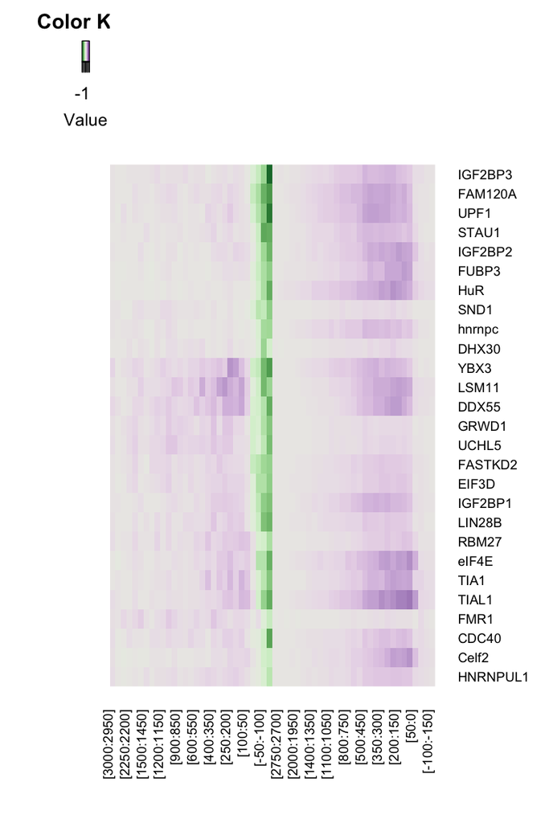

```r
PlotHeatmapRegulators(mots=selMOTS,mymats=list(ttest_APA_NGF_Ip[,-1],-ttest_APA_NGF_Id[,-1]))
```